# Empty-set experiment prep

### identify and exclude trials with extremely long reading times

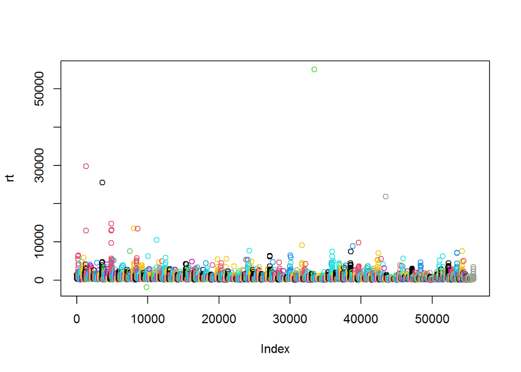

```r
melt_data_read <- subset(melt_data, roi!= "pictureRT" & !is.na(melt_data$rt))#TODO: move up?
with(melt_data_read, plot(rt, col=participant_id))
```

```r
cutoff_ex_rt <- 15000
ex_rt <- melt_data_read[melt_data_read$rt>cutoff_ex_rt | melt_data_read$rt< 0,][c("prolific_id", "trial")]
key <- c("prolific_id", "trial")
melt_data<-  melt_data[!interaction(melt_data[key]) %in% interaction(ex_rt[key]),]
```

### remove excluded pps

```r
melt_data <- subset(melt_data, !(prolific_id %in% exclude))
#with(melt_data, plot(sentenceRT, col=participant_id))
```

### check how many pps remained

```r
length(unique(melt_data$participant_id))
```

```
## [1] 76
```

### use trimr to trim sentence rt

```r
trimmed_data <- melt_data
trimmed_data$participant <- trimmed_data$participant_id
trimmed_data$condition <- as.factor(paste(trimmed_data$subexperiment,trimmed_data$roi))
trimmed_data$accuracy <- 1 #(accuracy only because trimr needs this colmun name to function)


trimmed_data <- sdTrimBugFixed(data = trimmed_data, minRT = 150, sd = 2.5,
                       perCondition = TRUE, perParticipant = TRUE,
                       omitErrors = FALSE, returnType = "raw", digits = 0)
```

### convert to factor

```r
trimmed_data$participant_id <- droplevels(as.factor(trimmed_data$participant_id))
```

### subset experiments items from filler items

```r
trimmed_data_exp1 <- subset(trimmed_data, subexperiment == 1)
trimmed_data_exp2 <- subset(trimmed_data, subexperiment == 2)
trimmed_data_exp3 <- subset(trimmed_data, subexperiment == 3)
trimmed_data_fillers <- subset(trimmed_data, !(subexperiment %in% c(1,2,3)))
```

##Exp1 ### name quantifier types, Exp1

```r
trimmed_data_exp1 <- trimmed_data_exp1 %>%
  mutate(quantifier = case_when(cond == 2 | cond == 6 | cond == 10 | cond == 14 ~ "no",
                                   cond == 4 | cond == 8 | cond == 12 | cond == 16 ~ "at_most_one",
                                   cond == 1 | cond == 5 | cond == 9 | cond == 13 ~ "exactly_one",
                                   cond == 3 | cond == 7 | cond == 11 | cond == 15 ~ "at_least_one"))
```

### name quantifier classes, Exp1

```r
trimmed_data_exp1 <- trimmed_data_exp1 %>%
  mutate(degree_quantifier = case_when(cond == 2 | cond == 6 | cond == 10 | cond == 14 ~ "no",
                                cond == 4 | cond == 8 | cond == 12 | cond == 16 ~ "yes",
                                cond == 1 | cond == 5 | cond == 9 | cond == 13 ~ "no",
                                cond == 3 | cond == 7 | cond == 11 | cond == 15 ~ "yes"))
```

### change empty_set_quantifier label

```r
trimmed_data_exp1$empty_set_quantifier <- ifelse(trimmed_data_exp1$empty_set_quantifier == "1", "yes", "no")
```

### estimate random effect and compute pseudo residuals

```r
trimmed_data_fillers_judge <- subset(trimmed_data_fillers, roi=="pictureRT")
trimmed_data_fillers_judge$quantifier <- str_split(trimmed_data_fillers_judge$sentence, " ", n = 2, simplify = TRUE)[,1]

trimmed_data_fillers_read <- subset(trimmed_data_fillers, roi!="pictureRT")
trimmed_data_fillers_read$quantifier <- str_split(trimmed_data_fillers_read$sentence, " ", n = 2, simplify = TRUE)[,1]


resp_lmer <- lmer(rt~response+(1+response|participant_id), data=trimmed_data_fillers_judge)
```

```
## boundary (singular) fit: see help('isSingular')
```

```r
isSingular(resp_lmer) #(NB: should we deal with the singularity?)
```

```
## [1] TRUE
```

```r
#compute pseudo residuals
trimmed_data_exp1_judge <- subset(trimmed_data_exp1, roi=="pictureRT")
trimmed_data_exp1_judge$response_num <- ifelse(trimmed_data_exp1_judge$response == "True", 1, 0)
trimmed_data_exp1_judge$resid_rt <- trimmed_data_exp1_judge$rt -
  trimmed_data_exp1_judge$response_num *
     (fixef(resp_lmer)[2]+
        ranef(resp_lmer)$participant_id[trimmed_data_exp1_judge$participant_id,2])
#the follwoing leads to negative resid_rt difficult for log transformation
#trimmed_data_exp1_judge$resid_rt <- trimmed_data_exp1_judge$rt -
#  (ranef(resp_lmer)$participant_id[trimmed_data_exp1_judge$participant_id,1] +
#     trimmed_data_exp1_judge$response_num *
#     (fixef(resp_lmer)[2]+
#        ranef(resp_lmer)$participant_id[trimmed_data_exp1_judge$participant_id,2]))
```

### encode models

```r
trimmed_data_exp1_judge$model_judge <- ifelse(trimmed_data_exp1_judge$model == "1", "0-model",
                                        ifelse(trimmed_data_exp1_judge$model == "1,1", "1-2-model",
                                               ifelse(trimmed_data_exp1_judge$model == "1,2", "1-2-model",
                                                      ifelse(trimmed_data_exp1_judge$model == "0,1", "1-2-model",
                                                             ifelse(trimmed_data_exp1_judge$model == "0", "0-model", "1-2-model")))))
```

```r
trimmed_data_exp1_judge$model <- ifelse(trimmed_data_exp1_judge$model == "1", "0-model",
                                        ifelse(trimmed_data_exp1_judge$model == "1,1", "1-model",
                                               ifelse(trimmed_data_exp1_judge$model == "1,2", "2-model",
                                                      ifelse(trimmed_data_exp1_judge$model == "0,1", "1-model",
                                                             ifelse(trimmed_data_exp1_judge$model == "0", "0-model", "2-model")))))
```

### excluding the 4 controls

```r
trimmed_data_exp1_judge_excl_control <- subset(trimmed_data_exp1_judge, trimmed_data_exp1_judge$cond < 13)
#na.exclude(trimmed_data_exp1_judge_excl_control) (NB: vermutlich hier nicht relevant?)

#controls only
trimmed_data_exp1_judge_control_only <- subset(trimmed_data_exp1_judge, trimmed_data_exp1_judge$cond > 12)
```

```r
trimmed_data_exp1_read <- subset(trimmed_data_exp1, roi!="pictureRT")
```

```r
trimmed_data_exp1_read_excl_control <- subset(trimmed_data_exp1_read, trimmed_data_exp1_read$cond < 13)
trimmed_data_exp1_read_control_only <- subset(trimmed_data_exp1_read, trimmed_data_exp1_read$cond > 12)
```

### saving all

```r
save(trimmed_data_exp1,trimmed_data_exp2,trimmed_data_exp3,trimmed_data_fillers, trimmed_data_fillers_judge,trimmed_data_fillers_read, trimmed_data_exp1_judge, trimmed_data_exp1_judge_excl_control, trimmed_data_exp1_judge_control_only, trimmed_data_exp1_read, trimmed_data_exp1_read_excl_control, trimmed_data_exp1_read_control_only,
     file = "trimmedData.RData")
```

### TODO: split file here to analyze subexperiments separately

```r
load("trimmedData.RData")
```

#1st steps: # merge all participants into one dataframe - done with the python skript in R

# extract the different reading times from string format to new columns (one column for each region)

# -> Hening will adapt his R skript for that

# critical regions will be the last region for every item

# do a histogram how many of the (in percent) participants have 16, 17, 18, 19, 20 of the real Filler (6500-8400) correct

# depending on that we choose to exclude partcipants that have at least 80%, 85% or 90% of these fillers correct

#90% only if we don’t loose more than 20% of the data (we could get 20 percent more data)

# we agreed to have a look at those that took very long

# but in general want to concentrate on excluding with the real Filler

#handing over to Nadine 22nd of August

#Analysis

# we want to look at all reading time regions at first and then focus especially on the critical region and the one before

#judgements with logit mixed effect regression analysis (glm - binomial logit) #latencies (log transformed) with (g)lmer # check picture verification times # do seperate analysis - one for all picture verification times, one for those with correct response, one for those with wrong responses #we should chekc wheter there is actually an effect with random interecepts of items - otherwise we could leave it out (there is no real item difference)